# Exploring the BRFSS Data

# Behavioral Risk Factor Surveillance System

**Useful Resources**  
Codebook  
[Dataset Documentation](https://www.cdc.gov/brfss/annual_data/2013/pdf/Overview_2013.pdf)

**Structure of this Workbook**

1. Data Background Information
2. Statement of Research Questions
3. Exploratory Data Analysis
   - Research Question 1
   - Research Question 2
   - Research Question 3

## Setup

### Load packages

```r
library(ggplot2)
library(dplyr)
library(psych)
library(tidyr)
```

### Loading data

```r
load("brfss2013.RData")
```

## Part 1: Data

According to the dataset documentation, this BRFSS data was collected in 2 main ways:

1.Landline telephone surveys

- When conducting the landline surveys, adults were randomly selected in a household.

2.Cellular telephone survers

- When conducting the cell phone surverys, the subjects were adults who have cell phones and resides in either a private residence or college housing.

The subjects were from all 50 states and some US territories.  
Quoting from the official [CDC BRFSS Data Documentation](https://www.cdc.gov/brfss/data_documentation/pdf/UserguideJune2013.pdf)…

> States may determine that they would like to sample by county, public health district or other sub-state geography in order to make comparisons of geographic areas with their states. In order to conduct the BRFSS, states obtain samples of telephone numbers from CDC. States then review their sampling methodology with a state statistician and CDC to make sure data collection procedures are in place to follow the methodology.

Additional key pieces of information regarding sampling methodology are as follows:

- Overall: Geographic Stratification
- Landline Survey: Telephone numbers (Further Stratified Sampling) & Respondent (Random Sample)
- Cell Phone Survey: Cluster sampling (per state’s particular method) & random sampling

Thus, the sampling methodology for the survery allows for generalization of findings because of the random sampling. However, given this is an observational study (not an experiment), findings do not prove causality.

## Part 2: Research questions

**Research quesion 1:**

*How does sleep affect physical and mental health as you age?*  
It is no secret that sleep is important and often overlooked by many people, but I would love to compare physical and mental health between different age group-sleep time combinations.

**Research quesion 2:**

*Is there a correlation between alcohol consumption, tobacco use, and income?*  
Alcohol consumption and tobacco use are often looked at as “vices” or “guilty pleasures” for many people. I am interested in exploring the usage of these activities among different groups of income categories to see if they can also serve as predictors of income.

**Research quesion 3:**

*Is there a relationship between sodium intake and physical/mental health?*  
In my experience, most people that closely monitor their food consumption pay more attention to micro and macro nutrients than sodium intake. Personally, I watch what I eat closely, but without regard to how much sodium I consume. It would be interesting for me to see if the self-reported data on physical/mental health varies between subjects with different consumptions of sodium.

## Part 3: Exploratory Data Analysis

### Research quesion 1:

*How does sleep affect physical and mental health as you age?*

Let’s start by looking at sleep time by age groups.

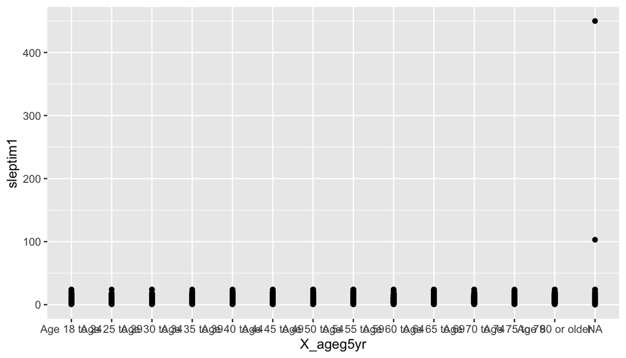

```r
ggplot(brfss2013,aes(X_ageg5yr,sleptim1))+geom_point()
```

This didn’t work out very well. X_ageg5yr is a categorical variable that contains approximately 5 year age groups. sleptim1 is a discrete variable that *should* be between 1-24, so it looks like there are outliers (100 and 450) that should be removed.

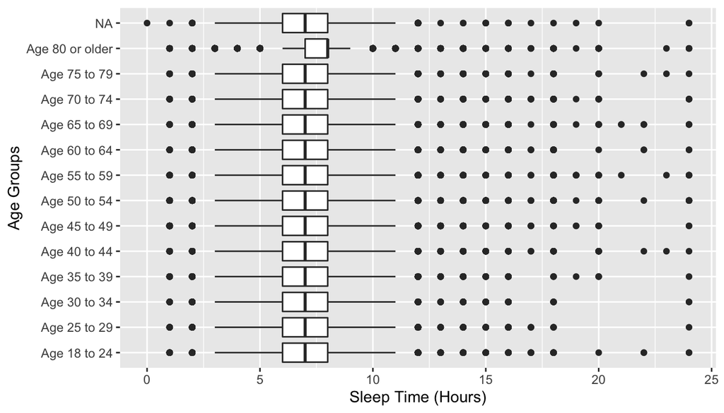

```r
# Removing outliers
sleptim_ol_rem <- brfss2013 %>% filter(sleptim1<=24)
# Plotting vertical bar plots
ggplot(sleptim_ol_rem,aes(x=X_ageg5yr,y=sleptim1))+
  geom_boxplot() +
  coord_flip() +
  labs(x="Age Groups",y="Sleep Time (Hours)")
```

This doesn’t appear to show any differences between reported sleep time among the age groups. It may be too distributed. Let’s try this with bigger age groups. I’ll do this manually by dividing X_age80 (numerical variable ranging from 18-80) into 5 groups…

1. 18-32
2. 33-44
3. 45-56
4. 57-68
5. 69-80

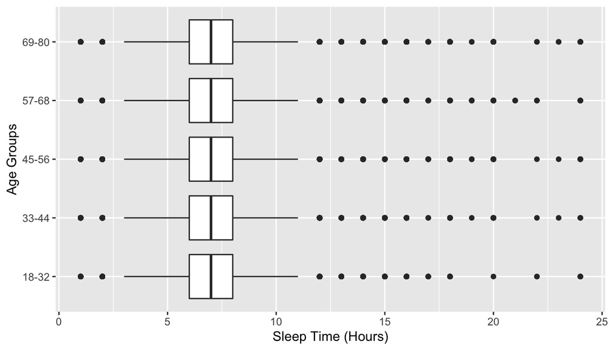

```r
# Making cuts to create 5 age groups
b = c(18,32,44,56,68,80)
l = c("18-32","33-44","45-56","57-68","69-80")
sleptim_ol_rem$age_g_5 <- cut(sleptim_ol_rem$X_age80,breaks=b,labels=l)

# Replotting (And removed NAs for age since their age is unknown)
sleptim_ol_rem_age <- sleptim_ol_rem %>% filter(!is.na(age_g_5))
ggplot(sleptim_ol_rem_age,aes(x=age_g_5,y=sleptim1))+
  geom_boxplot() +
  coord_flip() +
  labs(x="Age Groups",y="Sleep Time (Hours)")
```

This is a bit easier to read. Still unhelpful since it doesn’t show any apparent trends in sleep patterns between the age groups. So let’s change our strategy and just create a categorical variable with 2 values: Inadequate sleep (<=6 hours) and Adequate sleep (>6 hours), then use that as a fill to compare phys health between age groups.

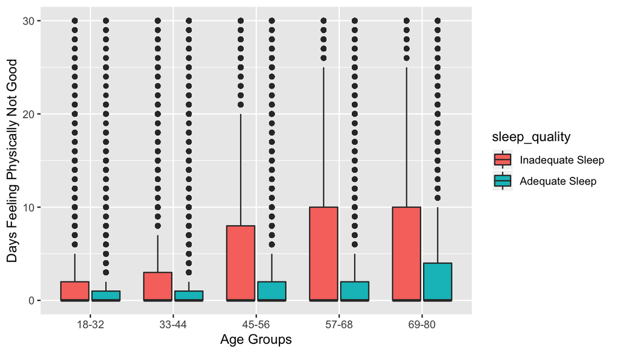

```r
# Creating the categories
b <- c(0,6,24)
l <- c("Inadequate Sleep","Adequate Sleep")
sleptim_ol_rem_age$sleep_quality <- cut(sleptim_ol_rem_age$sleptim1,breaks=b,labels=l)

ggplot(sleptim_ol_rem_age,aes(x=age_g_5,y=physhlth,fill=sleep_quality))+
  geom_boxplot() +
  labs(x="Age Groups",y="Days Feeling Physically Not Good")
```

That’s interesting! So I interpret this as the following…

> **Older people** tend to feel physically not good **more often** when they get **inadequate sleep** (<=6 hours).

Let’s see this same analysis on mental health.

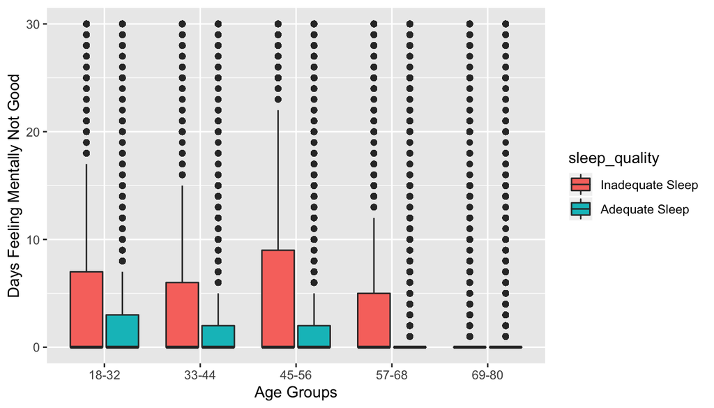

```r
ggplot(sleptim_ol_rem_age,aes(x=age_g_5,y=menthlth,fill=sleep_quality))+
  geom_boxplot() +
  labs(x="Age Groups",y="Days Feeling Mentally Not Good")
```

This is surprising! I’m interpretting this as the following…

> **Younger people** tend to feel mentally not good **more often** when they get **inadequate sleep** (<=6 hours).

### Research quesion 2:

*Is there a correlation between alcohol consumption, tobacco use, and income?*

Luckily, the dataset comes with some useful variables for this analysis.

Let’s start with looking at income2 (ordinal variable - income levels) for income and avedrnk2 (discrete variable - Avg alcoholic drinks per day).

Let’s remove NA values from income2 since these income levels aren’t reported.

```
## Warning: Removed 212571 rows containing non-finite values (stat_summary).
```

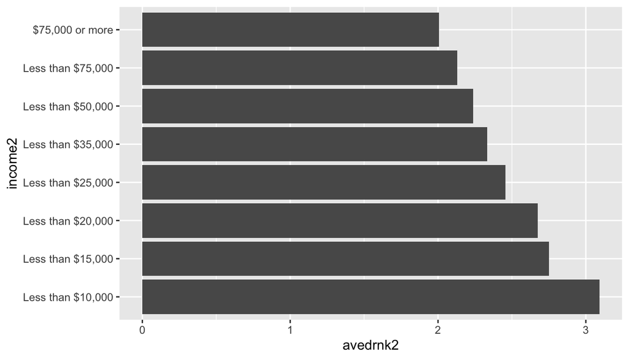

```r
# Removing NA Values
inc_no_na <- brfss2013 %>% filter(!is.na(income2))
# Plotting
ggplot(inc_no_na,aes(income2,avedrnk2))+stat_summary(geom="bar",fun.y = "mean") + coord_flip()
```

Now let’s just add in a fill on X_smoker3.

```
## Warning: Removed 212571 rows containing non-finite values (stat_summary).
```

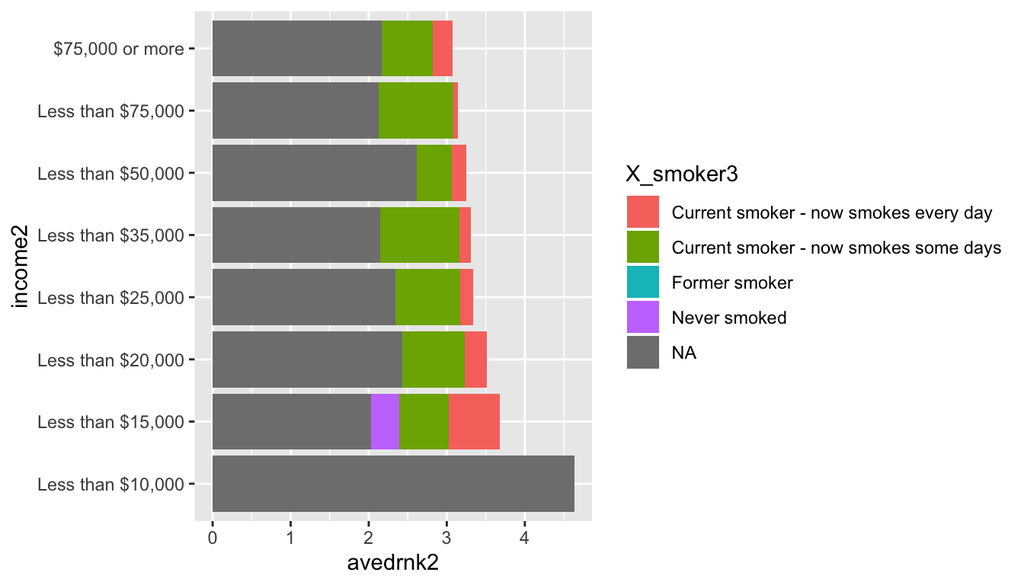

```r
ggplot(inc_no_na,aes(income2,avedrnk2,fill=X_smoker3))+stat_summary(geom="bar",fun.y = "mean") + coord_flip()
```

Lots of NA values in X_smoker3. This is a computed value that uses other variables. Let’s see if smokday2 provides a more helpful view.

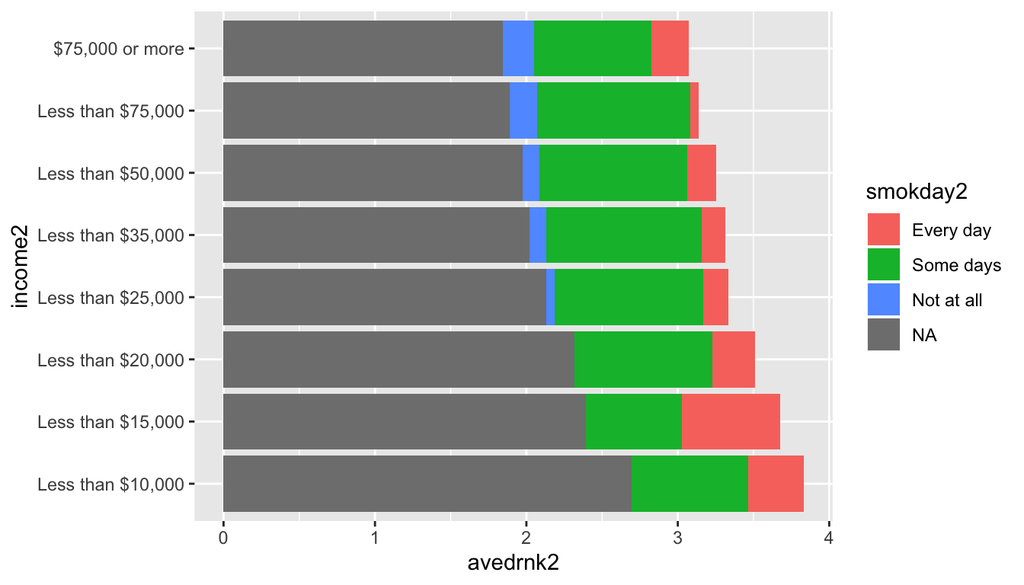

```r
ggplot(inc_no_na,aes(income2,avedrnk2,fill=smokday2))+stat_summary(geom="bar",fun.y = "mean") + coord_flip()
```

This is a bit better.

It is also worth calling out the non-responses or potential risk of inaccurate responses within these “sin” categories. As always with observational studies, these findings should be taken with a grain of salt.

### Research quesion 3:

*Is there a relationship between sodium intake and physical/mental health?*

The ‘wtchsalt’ variable has 2 main values (Yes/No) and many missing/refused/don’t know. It’s an optional module (states can decide whether or not to ask the questions), so it makes sense that many values are missing.

```r
brfss2013 %>% group_by(wtchsalt) %>% summarise (count=n())
```

```
## # A tibble: 3 x 2
##   wtchsalt  count
##   <fct>     <int>
## 1 Yes       74389
## 2 No        53638
## 3 <NA>     363748
```

I’m only concerned about the non-NA values, so I’ll filter them out. For convenience, I’ll assign the dataset with NA’s filtered out to a new DataFrame.

```r
brfss_wslt_nona <- brfss2013 %>% filter(!is.na(wtchsalt))
```

```r
sapply(brfss_wslt_nona %>% select(X_bmi5,wtkg3,physhlth,menthlth),class)
```

```
##    X_bmi5     wtkg3  physhlth  menthlth
## "integer" "integer" "integer" "integer"
```

Okay so these are all numeric data that can be summarized. Let’s look at the max and min values for each of them to see if there are any obvious outliers.

```r
sodium_analysis <- brfss_wslt_nona %>% select(X_bmi5,wtkg3,physhlth,menthlth,wtchsalt)

describe(sodium_analysis)
```

```
##           vars      n    mean      sd median trimmed     mad  min   max
## X_bmi5       1 122000 2796.38  620.42   2695 2734.93  520.39 1233  9145
## wtkg3        2 123397 8030.40 2036.89   7711 7861.23 2017.82 2268 27216
## physhlth     3 125645    4.38    8.89      0    1.88    0.00    0    30
## menthlth     4 126164    3.32    7.69      0    1.08    0.00    0    30
## wtchsalt*    5 128027    1.42    0.49      1    1.40    0.00    1     2
##           range skew kurtosis   se
## X_bmi5     7912 1.34     3.78 1.78
## wtkg3     24948 1.07     2.57 5.80
## physhlth     30 2.15     3.21 0.03
## menthlth     30 2.63     5.82 0.02
## wtchsalt*     1 0.33    -1.89 0.00
```

- By looking at the “max” column of this table, it looks like BMI *might* have outliers. It’s implied there are 2 decimal places, so the maximum value is 91.45. Over 30 is considered obese, so this may be an error. We’ll plot it later just to see what the distribution looks like.
- Wtkg3 might have outliers as well. This should be in kilograms with 2 decimal places, and so shows that the maximum value in the wtkg3 is 272.16kg. This could very well be a valid value, though. I’ll take a look at the plot just to see what the distribution looks like.
- Physhlth and Menhlth seem okay. No obvious outliers there.

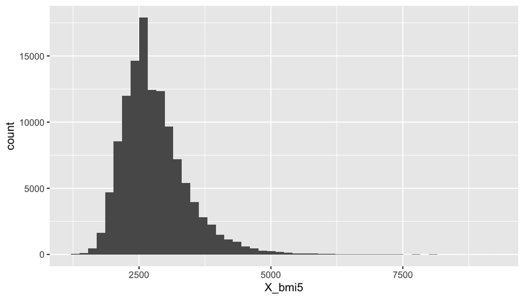

```r
ggplot(sodium_analysis,aes(X_bmi5))+geom_histogram(bins=50)
```

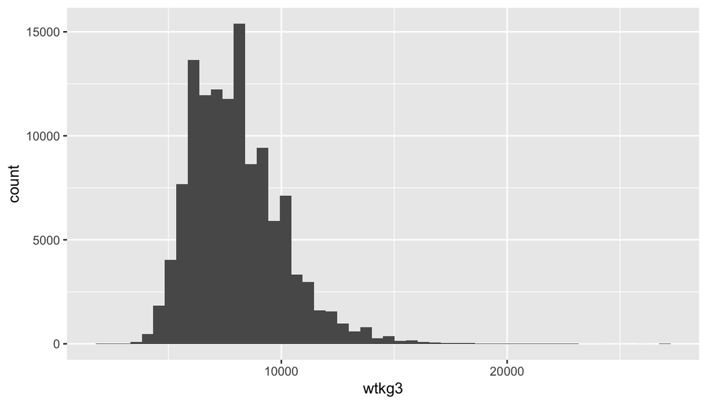

```r
ggplot(sodium_analysis,aes(wtkg3))+geom_histogram(bins=50)
```

Both distributions show some huge outliers, and I don’t want these outliers to affect my comparison because I’m going to aggregate these values between the “Yes” group and the “No” group, so I’m going to filter out X_bmi5>5500 and wtkg3>16500.

```r
sodium_analysis <- sodium_analysis %>% filter(X_bmi5<=5500,wtkg3 <= 16500)
```

Now I’m going to group these by wtchsalt and aggregate by mean. Just for convenience, I’m going to filter out NAs, however I realize this may not be a very valid approach to dealing with missing values.

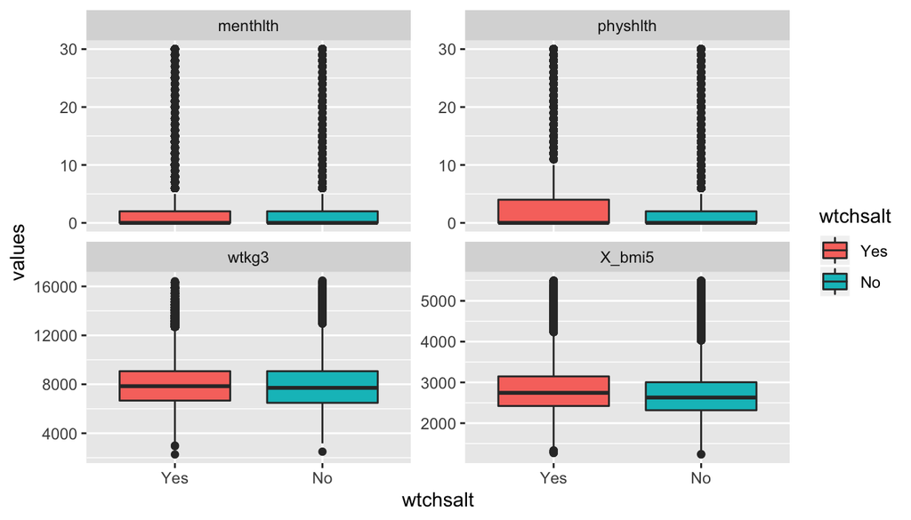

```r
# Filtering out NA's
sa_no_na <- sodium_analysis %>% group_by(wtchsalt) %>% filter(!is.na(X_bmi5),!is.na(physhlth),!is.na(menthlth))

# Using gather to create a long form of the data for plotting
sa_no_na_long <- tidyr::gather(sa_no_na,key=metric,value=values,-wtchsalt)

# Plotting using facet_wrap to see several box plots
ggplot(sa_no_na_long,aes(x=wtchsalt,y=values,group=wtchsalt))+
  geom_boxplot(aes(fill=wtchsalt))+facet_wrap(metric ~ ., scales = "free_y")
```

**Conclusion** By looking at these boxplots, it doesn’t seem like the population that responded “Yes” to wtchsalt differred very highly from the population that responded “No” to wtchsalt. The biggest differences I see are that the “Yes” group seemed to have more days in which they felt physically bad (physhlth) and had a higher calculated body mass index (X_bmi). This is contary to what I would have expected, but I suppose a confounding factor is that people that watch salt may choose to do so because they may be in slightly worse physical condition than those who do not watch their salt intake. In conclusion, I have no significant discoveries on whether salt affects physical or mental well being per the analysis above.